# Automatic Differentiation

In today's post, I want to talk about what automatic differentiation is and give you a simple method for implementing automatic differentiation in your code. Today's post will use Python as the language of choice, but everything said here generalizes to other programming languages. Automatic differentiation is a way to efficiently and accurately calculate derivatives of functions from their computer code, but before we get to automatic differentiation, let's talk about why you should want to compute derivatives in the first place!

## The Utility of Derivatives

### The Newton Method

The first example we will use to illlustrate why derivatives are useful for many numerical algorithms is the [Newton method](https://en.wikipedia.org/wiki/Newton%27s_method). The Newton method is a simple iterative technique for estimating the root of a function. Given a function $f(x)$ (which may be nonlinear or quite complciated), we want to find a value for $x^\ast$ that is a root, meaning that $f(x^\ast) = 0$.

The Newton method is simple to derive. It's based on a [Taylor series](https://en.wikipedia.org/wiki/Taylor_series) expansion. Near a point $a$, we can approximate $f(x)$ as a linear polynomial given the value of $f(a)$ and the derivative at that point $f'(a)$: $$ f(x) \approx f(a) + f'(a)(x-a) $$ Suppose we can at least make a guess $\hat{x}$ for the root $x^\ast$. If our guess isn't too bad, it'll be close to $x^\ast$. We can use the linear polynomial approximation from the Taylor series to "measure" how bad our guess is. If $\hat{x}$ was correct, then $f(\hat{x}) = 0$ and we'd have found our root. Based on the sign of $f(\hat{x})$ and the sign of $f'(\hat{x})$, we can figure out which direction the root is. And we can compute a correction to our guess. Basically you plug $\hat{x}$ into the Taylor polynomial and solve for $x^\ast$. $$ f(x^\ast) = 0 \approx f(\hat{x}) + f'(\hat{x})(x^\ast - \hat{x}) $$ Which means that $$ x^\ast \approx \hat{x} -\frac{f(\hat{x})}{f'(\hat{x})} $$ Note that since the Taylor polynomial is not an exact representation of $f$, we don't get an exact solution by solving it. But we can prove that it's a better guess if we consider the higher order terms. First, let's compute how about our initial guess, then how bad the new guess is. $$ \begin{align} 0 &= f(\hat{x}) + f'(\hat{x})(x^\ast - \hat{x}) + \frac{1}{2}f''(\hat{x})(x^\ast - \hat{x})^2 + \cdots\\ 0 &= f(\hat{x}) + f'(\xi)(x^\ast - \hat{x})\\ \frac{-f(\hat{x})}{f'(\xi)} &= x^\ast - \hat{x} = \varepsilon \end{align} $$ The second step follows from the [Mean Value Theorem](https://en.wikipedia.org/wiki/Taylor%27s_theorem#Explicit_formulas_for_the_remainder), where the remainder depends on the error $\varepsilon = x^\ast - \hat{x}$ and is equal to $f'(\xi)\varepsilon $ for some value $\xi \in [x^\ast,\hat{x}]$. This means that the error in our guess is proprortional to how much $f(\hat{x}$ differs from zero. If the function is changing a lot around it's root, then this error won't be very large because $f'(x)$ is large and therefore it's reciprocal is small. Now if we update our guess using Newton's method, what's the error? $$ \begin{align} 0 &= f(\hat{x}) + f'(\hat{x})(x^\ast - \hat{x}) + \frac{1}{2}f''(\hat{x})(x^\ast - \hat{x})^2 + \cdots\\ 0 &= f(\hat{x}) + f'(\hat{x})(x^\ast - \hat{x}) + \frac{1}{2}f''(\xi)(x^\ast - \hat{x})^2 \\ \hat{x} -\frac{f(\hat{x})}{f'(\hat{x})} &= x^\ast + \frac{1}{2}\frac{f''(\hat{\xi})}{f'(\hat{x})}(x^\ast - \hat{x})^2 \\ \frac{1}{2}\frac{f''(\xi)}{f'(\hat{x})}(x^\ast - \hat{x})^2 &= \varepsilon' \end{align} $$ The remainder shows that the error of the new guess is proportional to the square of the error in the old guess. For guesses that start close enough to the correct value, the square of the error is smaller. Also if the curvature of the function (as determined by the second derivative $f''$) is small near the root, then the error after an update will be very small.

Under certain conditions (which we won't derive here), repeating this process over and over will cause our guesses to get better and better. We generate a sequence of guesses $\hat{x}_0, \hat{x}_1, \hat{x}_2, \hat{x}_3, \ldots$ where each one is calculated from the last using the update step:

$$ \hat{x}_{n+1} = \hat{x}_{n} - \frac{f(\hat{x}_n)}{f'(\hat{x}_n)} $$

In fact, we can make any guess as good as we want. And that's exactly what a limit) is! So in the limit of infinitely many of iterations, this estimate converges.

$$ \lim_{n\to\infty} \hat{x}_n = x^\ast $$

Let's look at a numerical example, where we calculate $\sqrt{2}$. Our function is the polynomial $f(x) = x^2 - 2$ and it's derivative is $f'(x) = 2x$.

```
TRUE               ESTIMATE           DIFFERENCE
1.4142135623730951 1.5                -0.08578643762690485
1.4142135623730951 1.4166666666666667 -0.002453104293571595
1.4142135623730951 1.4142156862745099 -2.1239014147411694e-06
1.4142135623730951 1.4142135623746899 -1.5947243525715749e-12
1.4142135623730951 1.4142135623730951 +0.0
1.4142135623730951 1.414213562373095  +2.220446049250313e-16
1.4142135623730951 1.4142135623730951 +0.0
1.4142135623730951 1.414213562373095  +2.220446049250313e-16
1.4142135623730951 1.4142135623730951 +0.0
1.4142135623730951 1.414213562373095  +2.220446049250313e-16
```

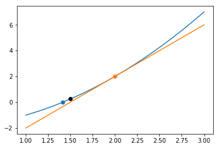

```python
import numpy as np
import matplotlib.pyplot as plt
%matplotlib inline

# FUNCTION WHOSE ROOT IS SQRT(2)
def f(x):
    return x**2 - 2

# DERIVATIVE OF f
def f_der(x):
    return 2*x

sqrt2 = np.sqrt(2) # for comparison
x = 2 # initial guess

# FOR PRETTY PRINTING OF OUTPUT
out = "{0:<} {1:<18} {2:<+18}"
print("{0:<18} {1:<18} {2:<18}".format("TRUE","ESTIMATE","DIFFERENCE"))

# COMPUTE TEN ITERATIONS
for _ in range(10):
    x -= f(x)/f_der(x) # ITERATION
    print(out.format(sqrt2, x, sqrt2 - x)) # PRINT EXACT VALUE, NEW ESTIMATE, AND DIFFERENCE

# PLOTTING THE LINEAR POLYNOMIAL APPROXIMATION
xx = np.linspace(1,3,101)
plt.plot(xx,f(xx))
plt.plot([sqrt2],[0],'oC0') # actual root
plt.plot([2],[f(2)],'oC1') # guess
plt.plot(xx,f(2) + f_der(2)*(xx-2),'C1')
plt.plot(2 - f(2)/f_der(2),f(2 - f(2)/f_der(2)), 'ok') # new guess
```

You can see that the Newton method converges very quickly! With a 3-4 iterations, we get an estimate that's accurate to 5-10 decimal places. Under the right conditions, the rate of convergence is quadratic. Intuitively that means every iteration doubles the correct number of decimal places. In fact, this is exactly the method that many calculators or computers use when you ask them to calculate $\sqrt{x}$. They apply Newton's method to $f(y) = y^2 - x$ and return the $y$ after the error goes down below the calculators' accuracy.

It's hard to beat Newton's method for speed and it works for higher dimensional functions too where the linearized version is $f(x) \approx f(a) + Df(a)(x-a)$ and the derivative is now a square matrix $Df(a)$ (called the [**Jacobian**](https://en.wikipedia.org/wiki/Jacobian_matrix_and_determinant)). So the update for the multidimensional version involves solving a linear system of equations (a matrix vector equation).

While it is possible to find the roots of functions without using the derivative, those methods are not usually as fast or efficient as the Newton method. To take an advantage of it's speed and simplicity, you need to calculate the derivative of the function. In this example, we calculated the derivative by hand as it's not too hard to do. But what if $f$ had been much more complicated, and getting the derivative involved several pages worth of algebra? Well besides being a tedious calculation to do by hand, you often make mistakes! So it's important to check your work if you do all that algebra to make sure you didn't make a mistake somewhere. Or better yet, if you can automate the process of calculating the derivative, you can skip all that algebra to begin with.

If I haven't convinced you yet of the utility, here's another example.

### Solving Optimization Problems

In many cases in science or applied math, we want to find the $x$ that minimizes a function $f(x)$ (or maximizes $-f(x)$). A good example is fitting curves or statistical models to data. These involve finding the minimum of a function (Note that the $x$ here isn't the $x$ in most statistical models. Statistical models use $x$ for data such as covariates rather the parameters $\theta$ which are the inputs we want to optimize for).

There are a number of different numerical algorithms for finding the solution to a minimization problem. Note that many algorithms assume a minimization problem, but you can convert a mazimization problem into a minimization problem by multiplying a function by $-1$. I won't go into the details of how these algorithms work, but I want to illustrate how algorithms which make use of the derivative of a function tend to be faster and more efficient computationally speaking than those that don't make those assumptions.

A lot of the fastest methods for optimization are based on the Newton method as discussed above. And these are called Newton methods. They require the first derivative (often called the gradient or jacobian) and sometimes also the second derivative (often called the hessian). A few methods will automatically approximate the first derivative using finite differences (more on this later), and these are called Quasi-Newton methods. They aren't as fast as the true Newton methods. Then there are non-Newton methods. Note we are only talking about local solution methods and not global ones which tend to not use derivative information at all (except that they might use a local minimization solver as part of their solution method). Maybe in the future we will do a post about these different solving techniques, but for now, we will use the methods provided by the scipy package in python to illustrate them. Methods also differ in whether or not they can deal with constraints (bounds/box, equality, inequality constraints)

Here's the definition for any $n$ dimensions : $$ f(x) = \sum_{i=1}^{n-1} 100\left(x_{i+1} - x_{i}^2 \right)^2 + \left(1 - x_i\right)^2 $$

The two dimension version is helpful for illustrating it's shape.

The Rosenbrock function always has a global minimum at $x = (1,1,\ldots,1)$ and for dimensions four through seven, it has a second minimum at $x = (-1,1,1,\ldots,1)$.

Here's what the 2D Rosenbrock function looks like:

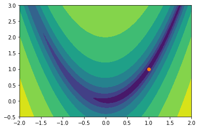

```python
from scipy.optimize import rosen, rosen_der, rosen_hess

X = np.mgrid[-2:2:101j,-0.5:3:101j]

Z = rosen(X)
plt.contourf(X[0],X[1],np.log(1 + Z)) # log scale for output to make differences easier to see
plt.plot(1,1,'oC1')
```

The point indicates the global minimum. You can see that Rosenbrock function has a banana shaped valley with very steep slopes. So the valley is relatively easy to find for most solvers, but because the curvature of the valley is hig, solvers can get take a while to find their way to the correct value.

Note we will solve the Rosenbrock function in 20 dimensions rather than 2. A 20 dimensional minimziation problem is not uncommon in statistics. In a recent manuscript, I used a model that 80+ parameters meaning that the minimization function had an 80+ dimensional space to search through to find a minimum. We'll use a random starting point somewhere around the true minimum using a normal distribution centered around the true minimum. In other words, this is a very good guess.

Scipy provides two methods that do not use first derivatives at all. The first is the Nelder-Mead method.

```python
from scipy.optimize import minimize

x0 = np.ones(20) + 0.1*np.random.randn(20) #random starting point
print(x0)
```

```
[1.05638606 1.10040121 0.97896815 1.00565717 1.14867093 0.95194389
 1.18221183 0.83533436 1.16062051 1.03115205 0.95065037 0.96990193
 0.91449134 1.04499377 1.20250546 0.95148757 1.0036862  0.96984868
 0.953091   0.7785705 ]
```

```python
sol = minimize(rosen,x0, method = 'Nelder-Mead')
print(sol)
```

```
 final_simplex: (array([[1.00009703, 1.00012706, 0.99999498, 1.00018384, 1.00011508,
        1.00013367, 1.00004759, 1.00005229, 0.99996854, 1.0000021 ,
        1.00000373, 1.00011413, 1.00024901, 1.0000202 , 1.00004301,
        1.00005956, 1.00005962, 0.9999803 , 0.99971616, 0.9993344 ],
       [1.00009695, 1.00012309, 0.99999456, 1.00018612, 1.00012211,
        1.0001551 , 1.00006699, 1.00008863, 0.9999554 , 0.99997375,
        0.99997691, 1.00007111, 1.00024879, 1.00002738, 1.00001889,
        1.00000808, 1.00002124, 0.99997878, 0.99976469, 0.99942696],
       [1.00014234, 1.00014246, 1.00000134, 1.00017781, 1.00007298,
        1.00009665, 1.00006521, 1.00007532, 0.99997154, 1.00001778,
        1.00000733, 1.00007258, 1.00026709, 1.00005281, 1.00002399,
        1.00005121, 1.00005958, 0.99996087, 0.99970739, 0.9993182 ],
       [1.00010174, 1.00014494, 1.00003017, 1.00022439, 1.00011397,
        1.00015452, 1.00007076, 1.00007116, 0.99993605, 0.99997948,
        0.99999047, 1.00011277, 1.00025934, 1.00004751, 1.00001149,
        1.00001693, 0.99998172, 0.99994615, 0.9997607 , 0.99940718],
       [1.00010246, 1.00014875, 1.00002535, 1.00018453, 1.00012841,
        1.00012911, 1.00003454, 1.00006132, 0.99995267, 0.99996939,
        0.99995766, 1.00009095, 1.00029716, 1.00008471, 1.00002607,
        1.00001519, 1.00002373, 0.99992946, 0.99973551, 0.99938762],
       [1.00013166, 1.00012014, 0.99995608, 1.00017896, 1.00010489,
        1.00014847, 1.00006686, 1.00008433, 0.99996471, 1.00000369,
        0.99999031, 1.00007298, 1.00026352, 1.00009353, 1.00007707,
        1.00003759, 1.00002566, 0.99993255, 0.99973746, 0.99939404],
       [1.00012831, 1.00012229, 0.99999054, 1.00012375, 1.00008817,
        1.00013224, 1.00005706, 1.00008062, 0.99998656, 1.00001693,
        0.99998683, 1.00012433, 1.00030918, 1.00009008, 1.00007066,
        1.00004188, 1.00004336, 0.99995295, 0.99972248, 0.99925955],
       [1.0001098 , 1.00013697, 1.00001946, 1.00016626, 1.00004836,
        1.00013242, 1.00005353, 1.0000874 , 0.99997046, 1.00002809,
        1.00000007, 1.00009844, 1.00028619, 1.00003861, 1.00004479,
        1.00005281, 1.00003587, 0.99993085, 0.9997095 , 0.99932583],
       [1.00006033, 1.00011334, 0.99998922, 1.00017347, 1.00008761,
        1.00012411, 1.00005419, 1.00006415, 0.9999785 , 1.00005074,
        1.00001662, 1.00011353, 1.00030901, 1.00006999, 1.00004169,
        1.00003204, 1.00002877, 0.99995014, 0.99972588, 0.99931832],
       [1.00008823, 1.000136  , 1.00003548, 1.00017879, 1.00011944,
        1.00017586, 1.00009333, 1.00009658, 0.99998614, 1.00002279,
        1.00002575, 1.00011111, 1.00032231, 1.00008467, 1.00004152,
        1.00000318, 0.99998838, 0.99990427, 0.99965513, 0.99931739],
```

[output cut: 44 more lines]

```
       6.17731696e-05, 6.21263530e-05, 6.26964016e-05, 6.31806454e-05,
       6.32056951e-05, 6.33516775e-05, 6.35080235e-05, 6.35557516e-05,
       6.35744650e-05, 6.36674691e-05, 6.42831676e-05, 6.45081231e-05,
       6.55960625e-05, 6.58752285e-05, 6.63552230e-05, 6.64846459e-05,
       6.65238202e-05]))
           fun: 5.909538777683505e-05
       message: 'Optimization terminated successfully.'
          nfev: 3100
           nit: 2421
        status: 0
       success: True
             x: array([1.00009703, 1.00012706, 0.99999498, 1.00018384, 1.00011508,
       1.00013367, 1.00004759, 1.00005229, 0.99996854, 1.0000021 ,
       1.00000373, 1.00011413, 1.00024901, 1.0000202 , 1.00004301,
       1.00005956, 1.00005962, 0.9999803 , 0.99971616, 0.9993344 ])
```

The output here gives us the solution under `sol['x']` as well as whether or not the solver thinks it was succesful `sol['success']`. More important is the number of iterations `sol['nit']` and the function calls `sol['nfev']`. It took 2421 iterations and nearly 3100 function calls to find our minimum (also notice that minimum is only accurate to within 3-4 decimal place)! We care more about the function calls than the number of iterations. The iteration number is not comparable between methods since methods might do a number of different things per iteration. The iteration number is useful for comparing the same method against different starting conditions (different initial guesses or different contraints) or against different functions. However, the number of function calls is rough estimate of the number of computations the solver has to do find a solution, and it's comparable between different methods.

The Rosenbrock function isn't hard to compute so it goes pretty fast in terms of actual time, but imagine if the function we were using was very expensive computationally speaking. If $f$ took 0.1 sec to evaluate (which is very slow for most computers), then it would take over five minutes to the minimum!!

What about the other method which only takes function calls?

```python
sol = minimize(rosen,x0, method = 'powell')
print(sol)
```

```
   direc: array([[ 1.33228301e-08,  3.92015395e-09, -7.92472390e-09,
        -1.39210331e-08, -1.98567995e-08, -3.03781918e-08,
        -1.72618997e-08, -1.09636155e-08,  2.93231429e-09,
         1.15339684e-08, -6.26904816e-09, -3.54348482e-08,
        -2.10136818e-08, -2.34171051e-08, -4.28194191e-08,
        -3.39957664e-08, -4.28906232e-08, -5.98274336e-08,
        -1.06976898e-07, -2.13953237e-07],
       [ 0.00000000e+00,  1.00000000e+00,  0.00000000e+00,
         0.00000000e+00,  0.00000000e+00,  0.00000000e+00,
         0.00000000e+00,  0.00000000e+00,  0.00000000e+00,
         0.00000000e+00,  0.00000000e+00,  0.00000000e+00,
         0.00000000e+00,  0.00000000e+00,  0.00000000e+00,
         0.00000000e+00,  0.00000000e+00,  0.00000000e+00,
         0.00000000e+00,  0.00000000e+00],
       [ 4.33992392e-09,  6.40122244e-10, -2.36974125e-09,
        -8.92825951e-10,  2.03786773e-10,  8.80171439e-10,
        -1.56145426e-09, -5.41855945e-09, -1.29905759e-09,
         1.40365616e-09, -7.83391328e-11, -1.84242059e-09,
         3.32325630e-10,  1.74522414e-09,  4.56698598e-09,
        -1.60025121e-09, -8.18961133e-09, -1.79378132e-08,
        -3.67473723e-08, -7.34947720e-08],
       [ 0.00000000e+00,  0.00000000e+00,  0.00000000e+00,
         1.00000000e+00,  0.00000000e+00,  0.00000000e+00,
         0.00000000e+00,  0.00000000e+00,  0.00000000e+00,
         0.00000000e+00,  0.00000000e+00,  0.00000000e+00,
         0.00000000e+00,  0.00000000e+00,  0.00000000e+00,
         0.00000000e+00,  0.00000000e+00,  0.00000000e+00,
         0.00000000e+00,  0.00000000e+00],
       [ 0.00000000e+00,  0.00000000e+00,  0.00000000e+00,
         0.00000000e+00,  1.00000000e+00,  0.00000000e+00,
         0.00000000e+00,  0.00000000e+00,  0.00000000e+00,
         0.00000000e+00,  0.00000000e+00,  0.00000000e+00,
         0.00000000e+00,  0.00000000e+00,  0.00000000e+00,
         0.00000000e+00,  0.00000000e+00,  0.00000000e+00,
         0.00000000e+00,  0.00000000e+00],
       [-2.11476421e-05, -2.55056005e-05, -2.52570059e-05,
        -2.22933493e-05, -1.77919948e-05, -1.29005968e-05,
        -9.12506551e-06, -6.38799511e-05, -3.04062942e-05,
         8.48766042e-06,  2.37173710e-05,  3.64323280e-05,
         7.15390493e-06,  5.35676917e-06, -3.73776107e-06,
```

[output cut: 93 more lines]

```
       [ 1.75241369e-10,  1.61859574e-10,  2.20074730e-10,
        -3.19268828e-11, -7.19975600e-11, -8.78138441e-11,
         5.89842855e-11,  3.50621497e-10,  1.48925017e-10,
         1.38473083e-10,  2.13125117e-10,  4.26248354e-10,
         3.95506251e-10,  4.42760063e-10,  6.66828348e-10,
         4.91236133e-10,  5.26855112e-10,  1.34921439e-09,
         2.85303477e-09,  5.70607080e-09]])
     fun: 5.237023271899662e-20
 message: 'Optimization terminated successfully.'
    nfev: 12074
     nit: 49
  status: 0
 success: True
       x: array([1., 1., 1., 1., 1., 1., 1., 1., 1., 1., 1., 1., 1., 1., 1., 1., 1.,
       1., 1., 1.])
```

The Powell takes fewer iterations and returns the exact solution, but nearly 4 times as many function calls!! If it took 0.1 sec to compute the function at each function call, this solution would take over 20 minutes!

Can we do better? Well, if the function has a derivative, we can use a Quasi-Newton method to approximate the derivative (this is done by finite differences, again see below for more). The Broyden-Fletcher-Goldfarb-Shanno (BFGS) algorithm has two versions, one where it uses the derivative we provide and one where it approximate the derivative with finite-differences. This is also the default algorithm if no method is specified and no constraints are provided.

```python
sol = minimize(rosen,x0,method = 'BFGS') # with approximate first derivative
print(sol)
```

```
      fun: 6.05038868246413e-11
 hess_inv: array([[ 1.64348667e-03,  8.06257355e-04,  4.04084155e-04,
         2.05869263e-04,  9.49474799e-05,  3.83589375e-05,
         1.76329604e-05,  2.12020270e-05,  8.51987703e-06,
         1.18928304e-05,  1.86873835e-05,  1.14604071e-05,
        -6.98014709e-06, -3.33975288e-05, -1.10368827e-05,
        -1.79636941e-05, -3.40424580e-05, -7.30371933e-05,
        -1.46471087e-04, -2.39875056e-04],
       [ 8.06257355e-04,  1.63944612e-03,  8.16988435e-04,
         4.06429558e-04,  1.97079875e-04,  9.14248054e-05,
         3.87133706e-05,  2.86674415e-05,  1.35350378e-05,
         1.44763012e-05,  1.96630416e-05,  9.35469056e-06,
        -7.15661017e-06, -3.08452922e-05, -1.50597962e-05,
        -3.08891157e-05, -4.77933313e-05, -9.54265166e-05,
        -1.80230784e-04, -3.16654375e-04],
       [ 4.04084155e-04,  8.16988435e-04,  1.64112140e-03,
         8.18580097e-04,  4.07165691e-04,  2.02245312e-04,
         9.70778437e-05,  4.06247894e-05,  3.13159669e-05,
         2.23343302e-05,  9.85890198e-06,  4.76691703e-06,
        -8.82770374e-06, -7.20144959e-06, -4.54507546e-06,
        -1.90723749e-05, -2.68582879e-05, -3.73032871e-05,
        -6.60017092e-05, -1.16386763e-04],
       [ 2.05869263e-04,  4.06429558e-04,  8.18580097e-04,
         1.65329188e-03,  8.18358316e-04,  4.12583448e-04,
         1.97448722e-04,  9.02436779e-05,  5.36106161e-05,
         3.07956600e-05,  1.38706137e-05,  7.67536425e-06,
        -1.35546838e-06,  6.73292503e-07, -2.05277701e-06,
        -1.15474826e-05, -2.03262371e-05, -1.89933189e-05,
        -4.23363064e-05, -1.08406971e-04],
       [ 9.49474799e-05,  1.97079875e-04,  4.07165691e-04,
         8.18358316e-04,  1.64172745e-03,  8.19655610e-04,
         4.01816551e-04,  2.03537453e-04,  9.93609408e-05,
         5.18554003e-05,  3.14996004e-05,  1.54711626e-05,
         1.59403219e-06, -1.13623111e-05, -1.81039761e-05,
        -2.48741704e-05, -4.23249211e-05, -8.03611135e-05,
        -1.64691486e-04, -3.45013783e-04],
       [ 3.83589375e-05,  9.14248054e-05,  2.02245312e-04,
         4.12583448e-04,  8.19655610e-04,  1.64751481e-03,
         8.13674004e-04,  4.14487583e-04,  2.02761866e-04,
         1.06095083e-04,  6.30013498e-05,  2.97553563e-05,
```

[output cut: 101 more lines]

```
      jac: array([ 4.86149431e-07,  7.59267645e-06, -3.82584642e-06, -1.95336601e-06,
        1.85429306e-05, -1.91479647e-05,  2.94806070e-05, -2.26588345e-05,
        2.28670930e-05, -2.02004626e-06, -3.01724203e-06,  1.33238537e-06,
       -5.42210264e-06, -6.40709386e-08,  2.14115928e-05, -7.37403024e-06,
        1.60491015e-06, -8.50223326e-07,  9.09843375e-06, -4.58071086e-06])
  message: 'Desired error not necessarily achieved due to precision loss.'
     nfev: 2806
      nit: 28
     njev: 127
   status: 2
  success: False
        x: array([0.99999998, 0.99999998, 0.99999997, 0.99999997, 0.99999999,
       0.99999996, 0.99999999, 0.99999996, 0.99999998, 0.99999996,
       0.99999994, 0.99999991, 0.99999986, 0.99999977, 0.99999959,
       0.99999915, 0.99999833, 0.99999669, 0.99999339, 0.99998674])
```

Although the solver doens't think it found a solution because the it wasn't able to reduce the relative error enough, it did, in fact, find the solution. Note that numerical solvers aren't perfect in their automated convergence criteria.

The output tells us the number of times it used the first derivationve `njev` and the number of function calls. As we shall see below, the number of function calls is still high because the function must be evaluated several times to approximate the derivative. This slows down the solver so 0.1 sec per function call, this solution would still take several minutes to finish.

Let's now provide the first derivative for BFGS to use.

```python
sol = minimize(rosen,x0,jac=rosen_der, method = 'BFGS') # with exact first derivative
print(sol)
```

```
      fun: 3.504321832856981e-15
 hess_inv: array([[ 1.64347475e-03,  8.06245640e-04,  4.04080428e-04,
         2.05870087e-04,  9.49445796e-05,  3.83543485e-05,
         1.76326744e-05,  2.12072657e-05,  8.52002561e-06,
         1.18967556e-05,  1.86912582e-05,  1.14629042e-05,
        -6.97529301e-06, -3.34063108e-05, -1.10426201e-05,
        -1.79765796e-05, -3.40638513e-05, -7.30908174e-05,
        -1.46579737e-04, -2.40082788e-04],
       [ 8.06245640e-04,  1.63943514e-03,  8.16985475e-04,
         4.06429587e-04,  1.97075700e-04,  9.14195181e-05,
         3.87112284e-05,  2.86729658e-05,  1.35329902e-05,
         1.44788135e-05,  1.96671356e-05,  9.35666392e-06,
        -7.15221684e-06, -3.08571149e-05, -1.50708508e-05,
        -3.09091452e-05, -4.78253358e-05, -9.55013928e-05,
        -1.80382305e-04, -3.16949611e-04],
       [ 4.04080428e-04,  8.16985475e-04,  1.64112187e-03,
         8.18580659e-04,  4.07164415e-04,  2.02242176e-04,
         9.70770512e-05,  4.06274362e-05,  3.13150353e-05,
         2.23346531e-05,  9.86141366e-06,  4.76789794e-06,
        -8.82597802e-06, -7.20797545e-06, -4.55243689e-06,
        -1.90863082e-05, -2.68811080e-05, -3.73538729e-05,
        -6.61031177e-05, -1.16584780e-04],
       [ 2.05870087e-04,  4.06429587e-04,  8.18580659e-04,
         1.65329129e-03,  8.18355334e-04,  4.12583640e-04,
         1.97443763e-04,  9.02429588e-05,  5.36065836e-05,
         3.07937350e-05,  1.38691395e-05,  7.67428026e-06,
        -1.35604808e-06,  6.72795057e-07, -2.05577438e-06,
        -1.15454704e-05, -2.03228436e-05, -1.89854008e-05,
        -4.23241408e-05, -1.08394340e-04],
       [ 9.49445796e-05,  1.97075700e-04,  4.07164415e-04,
         8.18355334e-04,  1.64172014e-03,  8.19653936e-04,
         4.01807782e-04,  2.03538056e-04,  9.93516916e-05,
         5.18517644e-05,  3.14976369e-05,  1.54690149e-05,
         1.59467687e-06, -1.13698118e-05, -1.81171545e-05,
        -2.48845371e-05, -4.23387803e-05, -8.03905321e-05,
        -1.64756629e-04, -3.45160458e-04],
       [ 3.83543485e-05,  9.14195181e-05,  2.02242176e-04,
         4.12583640e-04,  8.19653936e-04,  1.64751594e-03,
         8.13671613e-04,  4.14487108e-04,  2.02761606e-04,
         1.06097442e-04,  6.29987853e-05,  2.97543635e-05,
```

[output cut: 101 more lines]

```
      jac: array([ 2.96877847e-07,  5.31907703e-07, -4.52670783e-07, -2.70006361e-07,
        4.53650393e-07, -9.50813783e-08,  1.13300855e-06, -1.38434288e-06,
        9.05417333e-07,  1.56106769e-07, -7.15402727e-07,  6.57094004e-08,
       -5.33965077e-07,  6.69550115e-07,  4.76240415e-07, -4.34775594e-07,
       -1.13715405e-07, -9.59165893e-08, -5.46493923e-07,  3.41554784e-07])
  message: 'Optimization terminated successfully.'
     nfev: 43
      nit: 29
     njev: 43
   status: 0
  success: True
        x: array([1.        , 1.        , 1.        , 1.        , 1.        ,
       1.        , 1.        , 1.        , 1.        , 1.        ,
       1.        , 1.        , 1.        , 1.        , 1.        ,
       1.        , 1.        , 1.00000001, 1.00000002, 1.00000004])
```

We can also compare to the Newton-CG method which requires we provide it the jacobian. This method actually approximates the Hessian so it can be much faster.

```python
sol = minimize(rosen,x0,jac=rosen_der,method = 'newton-cg')
print(sol)
```

```
     fun: 1.0049097530661164e-06
     jac: array([-0.00020946,  0.00239451, -0.00046236, -0.00313033,  0.00034279,
       -0.00740327, -0.00221931, -0.0053289 , -0.00148245, -0.00171567,
        0.000631  ,  0.001916  , -0.00242023,  0.00083069, -0.00299085,
        0.00255302,  0.01053969,  0.0421013 , -0.01569654, -0.00512088])
 message: 'Optimization terminated successfully.'
    nfev: 18
    nhev: 0
     nit: 15
    njev: 162
  status: 0
 success: True
       x: array([0.99999933, 0.99999809, 0.99999768, 0.99999606, 0.99999532,
       0.99999404, 0.99999471, 0.99999379, 0.99999507, 0.99999499,
       0.99999437, 0.99999308, 0.99998882, 0.99998019, 0.99995921,
       0.999913  , 0.99979845, 0.99959105, 0.9991781 , 0.99834959])
```

We see that it's pretty fast, but especially if the jacobian is easier to compute than the function itself (this happens sometimes). It won't be much faster if the jacobian is similar in computation time to the original function.

If we have the Hessian (the second derivative) however, we get another speed up!

```python
sol = minimize(rosen,x0,jac=rosen_der,hess = rosen_hess,method='newton-cg')
print(sol)
```

```
     fun: 1.0049343131582067e-06
     jac: array([-0.00020941,  0.00239437, -0.00046218, -0.0031305 ,  0.00034276,
       -0.00740335, -0.00221935, -0.00532891, -0.0014823 , -0.00171568,
        0.00063099,  0.00191599, -0.00242028,  0.00083073, -0.00299081,
        0.00255308,  0.01053992,  0.04210209, -0.0156968 , -0.00512099])
 message: 'Optimization terminated successfully.'
    nfev: 18
    nhev: 15
     nit: 15
    njev: 32
  status: 0
 success: True
       x: array([0.99999933, 0.99999809, 0.99999768, 0.99999606, 0.99999532,
       0.99999404, 0.99999471, 0.99999379, 0.99999507, 0.99999499,
       0.99999437, 0.99999308, 0.99998882, 0.99998019, 0.99995921,
       0.999913  , 0.99979844, 0.99959104, 0.99917809, 0.99834957])
```

This method finds the solution very quickly, using only 18 function calls, 32 jacobian calls, and 15 hessian calls.

Note for all of these methods, we used a pretty good starting point but methods with more derivatives would still be faster and more efficient for worse starting points.

```python
x0 = -2*np.ones(20) # bad startinng point

print("WITH JACOBIAN ONLY")
sol = minimize(rosen,x0,jac=rosen_der,hess = rosen_hess,method='newton-cg')
print(sol)

print("\nWITH HESSIAN")
sol = minimize(rosen,x0,jac=rosen_der,hess = rosen_hess,method='newton-cg')
print(sol)
```

```
WITH JACOBIAN ONLY
     fun: 3.7545049693111596e-06
     jac: array([ 0.0006036 , -0.00033908,  0.00107676, -0.00049773,  0.00026981,
       -0.00134002,  0.00031515, -0.00113137, -0.00024271, -0.000912  ,
       -0.00034122, -0.00074496,  0.00052762,  0.0019886 ,  0.00694006,
        0.02944069, -0.00850973, -0.00066417, -0.00020891, -0.00298005])
 message: 'Optimization terminated successfully.'
    nfev: 96
    nhev: 85
     nit: 85
    njev: 180
  status: 0
 success: True
       x: array([0.99999992, 0.99999983, 0.99999975, 0.99999988, 0.99999967,
       0.99999973, 0.99999939, 0.99999917, 0.99999853, 0.99999779,
       0.99999566, 0.99999107, 0.9999799 , 0.99994986, 0.99989709,
       0.99979303, 0.99958506, 0.99916779, 0.99833036, 0.99664617])

WITH HESSIAN
     fun: 3.7545049693111596e-06
     jac: array([ 0.0006036 , -0.00033908,  0.00107676, -0.00049773,  0.00026981,
       -0.00134002,  0.00031515, -0.00113137, -0.00024271, -0.000912  ,
       -0.00034122, -0.00074496,  0.00052762,  0.0019886 ,  0.00694006,
        0.02944069, -0.00850973, -0.00066417, -0.00020891, -0.00298005])
 message: 'Optimization terminated successfully.'
    nfev: 96
    nhev: 85
     nit: 85
    njev: 180
  status: 0
 success: True
       x: array([0.99999992, 0.99999983, 0.99999975, 0.99999988, 0.99999967,
       0.99999973, 0.99999939, 0.99999917, 0.99999853, 0.99999779,
       0.99999566, 0.99999107, 0.9999799 , 0.99994986, 0.99989709,
       0.99979303, 0.99958506, 0.99916779, 0.99833036, 0.99664617])
```

So even with a bad starting point that's much, much further from the solution, we get there faster than we did with a good starting point but using method that didn't take advantage of the gradient.

MORAL OF THE STORY: USE AS MANY DERIVATIVES AS YOU CAN FOR OPTIMIZATION.

You can find list of all solver method available in `scipy.optimiize.minimize` on [this page](https://docs.scipy.org/doc/scipy-0.15.1/reference/generated/scipy.optimize.minimize.html#scipy.optimize.minimize).

## Automating the Calculation of Derivatives

If you took a calculus class, you almost certainly spent a number of homework assignments simply computing derivatives of all kinds of functions. And you could string these together using the chain rule and product rule and other ways for calculating derivatives. So you might be pretty good at calculating derivatives by hand. However, if you are good at calculating derivatives, it's not hard for functions to require several pages of algebra to get that derivative by hand. Even if you do that, it's easy to make a mistake (and using the wrong derivative is worse that not using a derivative at all). So at the very least, having a way to approximate the derivative would be useful to check our work by hand. And in many cases that approximation by might good enough.

## Finite Differences

The first way we'll talk about is very simple to implement and is fairly useful. Take the Taylor series expansion for $f(x+h)$ and solve $f'(x)$:

$$ \begin{align} f(x+h) &= f(x) + f'(x)h + \frac{f''(x)}{2} h^2 + \cdots\\ \frac{f(x+h) - f(x)}{h} &= f'(x) + \frac{f''(x)}{2} h^2 + \cdots\\ \frac{f(x+h) - f(x)}{h} &\approx f'(x) \end{align} $$

Note this is the same as the limit definition of the first derivative! This is called the **(forward) finite difference**. To approximate the function $f$, we need to take a small step to a nearby input, calculate the function at that point, then divide by the difference. The advantage of this method is you don't have to know anything about the internal structure of $f$ to get a estimate of its derivative. When solvers for optimization approximate derivatives, they use some variation on this technique (note you should never provide a method that assumes an exact derivative with an finite-difference estimate, there are special methods that handle better the associated error!). This approximation is also used in solving certain partial differential equations too!

There are a few other finite difference approximations. The backward and central difference for example. I won't show them here, the central difference is a bit more accurate.

Note that the finite difference method works for higher dimensions too. For each partial derivative you take a step jsut in that direction. Letting $e_0,e_1,e_2,\ldots$ be the standard basis (i.e., $e_1 = (0,1,0,0,\ldots)$). $$ \frac{\partial f}{\partial x_i} \approx \frac{f(x+h*e_i) - f(x)}{h} $$

The scipy package provides a function that automatically calculates this for a given function. Let's try it on the Rosenbrock function and compare the results!

```python
from scipy.optimize import approx_fprime

jac_true = rosen_der(x0) # correct jacobian

             # FOR PRETTY PRINTING OF OUTPUT
out = "{0:<2} {1:<18} {2:<18} {3:<+18}"
print("{:<2} {:<18} {:<18} {:<18}".format("", "TRUE","ESTIMATE","DIFFERENCE"))

# COMPUTE TEN ITERATIONS
for i in range(20):
    h = 0.1**i
    jac_approx = approx_fprime(x0,rosen,h)
    print(out.format(i,jac_true[0], jac_approx[0], jac_true[0] - jac_approx[0])) # PRINT EXACT VALUE, NEW ESTIMATE, AND DIFFERENCE
```

```
   TRUE               ESTIMATE           DIFFERENCE
0  -4806.0            -2705.0            -2101.0
1  -4806.0            -4533.800000000047 -272.19999999995343
2  -4806.0            -4778.069899999536 -27.930100000464336
3  -4806.0            -4803.199799905996 -2.80020009400414
4  -4806.0            -4805.719908035825 -0.2800919641749715
5  -4806.0            -4805.971990572288 -0.028009427712277102
6  -4806.0            -4805.9972032206115 -0.002796779388518189
7  -4806.0            -4805.999633390455 -0.00036660954538092483
8  -4806.0            -4805.999924428758 -7.55712417230825e-05
9  -4806.0            -4806.002834811804 +0.002834811803950288
10 -4806.0            -4805.915523320434 -0.08447667956625082
11 -4806.0            -4805.042408406732 -0.9575915932682619
12 -4806.0            -4802.132025361058 -3.8679746389416323
13 -4806.0            -4802.132025361058 -3.8679746389416323
14 -4806.0            -4365.574568510052 -440.4254314899481
15 -4806.0            0.0                -4806.0
16 -4806.0            0.0                -4806.0
17 -4806.0            0.0                -4806.0
18 -4806.0            0.0                -4806.0
19 -4806.0            0.0                -4806.0
```

We see that with a step size of $10^{-8}$ we get a pretty accurate estimate (to about 4 decimal places). We also see that smaller step sizes actually *make our worse*! Why is that?

It's not because we did something wrong mathematically. The error continues to decrease mathematically speaking, but the computer suffers from a second type of error: *cancellation error*. As $h$ gets very small, the difference $(f+h) - f(x)$ gets very small too. The computer only represents real numbers with so many digits and beyond that level of precision, it cannot exactly represent a real number, meaning that there are errors in this substraction. In the extreme, once $h$ is small enough, $f(x+h)$ is so close to $f(x)$ that they only differ somewhere in the 10+ decimal places. The computer ends up get a difference of zero rather than the correct amount. So we end up estimating a derivative of zero. You can see this happens above at $h \approx 10^{-15}$.

The errors in floating point operations are generally small, but if we aren't careful, under circumstances we can magnitude this error. Here's a few examples to illustrate floating point errors.

```python
0.1 + 0.2 # = 0.3?
```

```
0.30000000000000004
```

```python
1 - 0.2 - 0.2 - 0.2 - 0.2 - 0.2 # = 1 -0.2*5 = 0?
```

```
5.551115123125783e-17
```

How come both these answers are wrong, albeit not very? The computer represents all floating point numbers as binary numbers. And 0.1 can't be written exactly in base 2 without infinitely repeating digits in the same way that 1/3 = 0.333... in base 10. The same for 0.2, this means that the computer truncates those numbers to binary numbers that are very close to 0.1 and 0.2, but not exactly. And that error can add up.

In most computers today, they use IEEE-754 floating point arithmetic with 53 bits of precision (meaning it keeps track of 53 digits). That works out to be around 16 digits in base 10, so floating point arithmetic is usually accurate up to 15th decimal place and the error is one part in a quadrillion. You can read more about [floating point arithmetic limitations in python here](https://docs.python.org/2/tutorial/floatingpoint.html), but know that these limitations are common to basically [all computers and calculators](http://www.lahey.com/float.htm). That's because the way numbers are represented is directly built into the microchip processors in your computer. Floating point arithmetic isn't exact, but it's very, very fast as a result.

Luckily, we will discuss a method for approximating derivatives that circumvents this error!

## Symbolic Differentiation

It is possible to teach a computer to compute derivatives in the same way that you compute them on a piece of paper. The python package [Sympy](https://www.sympy.org/en/index.html) or SageMath and other [Computer Algebra Systems](https://en.wikipedia.org/wiki/Computer_algebra_system) can often take a written expression and manipulate it symbolically in a systematic way.

I am not going to go into detail here. In practice, this method isn't particularly flexible. It's also initially very slow (although you end up with an exact derivative at the end, which may not be slow to compute). But it's an option. The reason to mention symbolic differentiation is to contrast it with automatic differentiation which sounds similar but is very different in implementation.

## Automatic Differentiation

Automatic differentiation (also sometimes called algorithmic differentiation or computational differentiation) is a method for automating the calculation of derivatives. Unlike finite differences, automatic differentiation is much more accurate (to within machine precision) and does not suffer from the numerical problems that finite difference approximations do. Unlike symbolic differentiation where the computer takes a string of symbols and inteprets them using algorithims to manipulate the symbols, automatic differentiation is essentially a way of differentiating computer code directly.

Of course, I haven't told you exactly what automatic differentiation is yet. As one of the references I read for this piece stated, there's actually a number of ways of coming up with the basic ideas, making it seem more complicated than it is. We're going to start with dual numbers as a simple version, partly because I think it's easiest to see how to implement dual numbers. We will use a simple method to approximate dual numbers using complex numbers.

### Dual Numbers

Dual numbers are a lot like complex numbers. A complex number $z$ is composed of a pair of real numbers where one represents a real part and one represents the imaginary part. In other words, to make a complex number, you take the real numbers and you add in a special unit, called the imaginary unit $i$, with the rule that $i^2 = -1$. In general, you can write any complex number $z = x + iy$. From here, you can define arithmetic and a lot of calculus of real numbers on complex numbers. For instance, you can add, subtract, multiply, and divide as well as exponentiate, take logarithms, and extract roots! You can compute $\cos(z)$ and other transcendental functions too! It might not be obvious how to define those functions for complex numbers, but don't worry about that now. Things work out nicely for complex numbers.

Dual numbers are like complex numbers in that we start with the real numbers and add something. Instead of adding an imaginary unit $i$ with the defining rule $i^2 = -1$, we add a *dual* unit $\varepsilon$ with the rule $\varepsilon^2 = 0$. So a dual number is in general written as the pair $x + \varepsilon y $. Now operations and arithmetic are defined on dual numbers in the same way that we do for complex numbers. Let $z = x + \varepsilon y$ and $ w = u + \varepsilon v$ be two dual numbers.

Addition: $$ z + w = \left(x +u\right) \varepsilon \left(y + v\right) $$

That's what you'd expect. Things are a bit more interesting for multiplication. To multiply, we just multiply everything out as in regular algebra, and then collect the terms.

Multiplication: $$ zw = \left(x + \varepsilon y\right)\left(u + \varepsilon v\right) = xu + \left(xv + yu\right)\varepsilon + yv \varepsilon^2 = xu + \left(xv + yu\right)\varepsilon $$ The last equality follows from the rule that $\varepsilon^2 = 0$. Note that for the same reason, $\varepsilon^3,\varepsilon^4, \varepsilon^5,\ldots = 0$ because each term has a factor of $\varepsilon^2$.

So why does this help us compute derivatives? Let's look at an example with $f(x) = x^2$. If we apply $f$ to a dual number $x + \varepsilon$, what do we get?

$$ f(x + \varepsilon) = (x + \varepsilon)^2 = x^2 + 2x\varepsilon + \varepsilon^2 = x^2 + 2x\varepsilon $$

So we get another dual number, but if we split it into its real part and its dual part, we get $x^2$ and $2x$ which are the values of $f(x)$ and its derivative $f'(x)$! Does this work in general? Yes, let's take the Taylor serise expansion (technically we need to show that the Taylor series still works for dual numbers the way it does for real numbers, but we're going to lazy and informal and skip that rigorous proof). We'll pretend that the dual unit is just a real number to do the expansion then see what we get.

$$ f(x + \varepsilon) = f(x) + f'(x)\varepsilon + \frac{f''(x)}{2} \varepsilon^2 + \cdots $$

but the powers of $\varepsilon$ greater than 1 are all zero! So in fact, $$ f(x + \varepsilon) = f(x) + f'(x)\varepsilon $$ meaning that a function applied to a dual number is another dual number where the real part is the function applied to the real part and the dual part is the derivative of $f$ applied to the real part! In fact, to make this rigorous, we can actually use this as the definition $f$ on dual numbers. What I mean is that if you have a function $f$ on real numbers, and you want to convert it to a function on dual numbers, you can use the Taylor series expansion to define what $f$ should be on dual numbers (you can do something similar for complex numbers actually).

For example, what's $\sin(z)$ for a dual number $z = x + \varepsilon y$? Using our definition, $\sin(z) = \sin(x) +\varepsilon y \cos(x)$ because $\cos(x)$ is the derivative of $\sin(x)$ on real numbers.

So all operations we apply to dual numbers this way, we automatically have to compute the derivative as part of the definition. How does this automate the computation of derivatives? A really complicated function $f$ might compute a bunch of intermediate variables with simpler functions. E.g., maybe $ f(t) = f(x(t), y(t))$ where you compute some intermediate values $x$ and $y$ then use them in some computation. What happens when we apply this function to a dual number $t + \varepsilon$? The arithmetic of dual numbers automatically tracks and computes the chain rule and any other derivative combination rule. Here's the derivative of our example:

$$ \frac{df}{dt] = \frac{\partial f}{\partial x} \frac{\partial x}{\partial t} + \frac{\partial f}{\partial y} \frac{\partial y}{\partial t} $$

So when we apply those functions to dual numbers, what happens?

$$ x(t + \varepsilon) = x(t) + \varepsilon x'(t) \quad y(t + \varepsilon) = y(t) + \varepsilon y'(t) $$

and then applying $f$ to both of these dual numbers (using the Taylor series expansion as our definition): $$ f(x(t) + \varepsilon x'(t), y(t) + \varepsilon y'(t)) = f(x,y) + \varepsilon \left(\frac{\partial f}{\partial x}x' + \frac{\partial f}{\partial y}y'\right) $$

So if you were to define dual numbers in a computer and define functions on dual numbers, then anytime you wanted to compute a function on real numbers and its derivative, you simply use the dual number version. Basically, you are telling the computer to compute the derivatives for each computation along the way, no matter what computation it does. The arithmetic of dual numbers automates the rules of differentiation. Unfortunately, this isn't the easiest method to plug-and-play with, since you still need to define what dual numbers are and how to apply functions to them (which means you still have to tell the computer the derivative of everything elementary function). But once you do this, you now have a very flexible and fast way to compute derivatives of any function made up of those elementary functions.

In essence, all automatic differentation methods work this way. Typically they cannot handle functions which are not built from elementary functions that have derivatives defined in the library. The advantage is in quickly and accurately computing derivatives exactly where it would be hard to do by hand. Note that if we implement dual numbers into a computer, the derivatives would be computed as exactly as they could be if we had coded them by hand (to within machine precision, which means that any error results from the floating point arithmetic error only).

### The Complex Step Method

Since we don't have easy implementations of dual numbers already to use in python, we will instead use complex numbers to approximate the same thing. This is called the complex step method. The idea is that we add a very small step in the imaginary unit direction to a real argument $f(x + ih)$ where $h$ is very small. Let's expand this as Taylor series (don't worry Taylor series expansion work for all complex functions with derivatives so we don't need to worry about whether or not this expansion is valid):

$$ f(x + ih) = f(x) + f'(x)ih + \frac{1}{2}f''(x) (ih)^2 + \frac{1}{3!}f'''(x) (ih)^3 + \cdots $$

So we get a complex number $ w = f(x+ih)$ where the real part is all the even power terms and the imaginary part is all of the odd powers $$ \begin{align} \mathrm{Re}(w) &= f(x) - \frac{1}{2}f''(x) h^2 + \frac{f^{(4)}(x)}{4!}h^4 +\cdots\\ \mathrm{Im}(w) &= f'(x)h - \frac{1}{3!}f'''(x) h^3 + \frac{f^{(5)}(x)}{5!}h^5 \cdots \end{align} $$ The first terms of each of these series is the function's value and the function's derivative times are our step $h$, plus a number of other terms. We can approximate the derivative thus by computing $$ f'(x) \approx \frac{1}{h}\mathrm{Im}\left(f(x + ih)\right) $$ We can also compute $f(x) \approx \mathrm{Re}(f(x+ih))$ meaning you only have run through the calculations of $f$ once to get both the function's value and its derivative at that point. Though you do have to do more calculations because at each line of $f$, you use a complex number instead a real number.

What a minute, didn't I say that this would be an exact method? Why is this any different than the finite differences? Unlike finite differences, we don't suffer from that cancellation error here! We are not subtracting anything, just adding a very small bit and then dividing by it. This means that we don't lose any accuracy as $h$ gets smaller! Also, for the same step size $h$, this method converges much faster! The error in approximation depends on the square $h^2$ rather than $h$ for the forward finite difference. Let's illustrate that numerically!

```python
def f(x):
    return np.sqrt(x)

out = "{:>5} {:<20} {:<20} {:<20}"
print(out.format("POWER","FINITE DIFF", "COMPLEX STEP F", "COMPLEX STEP F' "))
h = 0.1
for i in range(17):
    diff = (f(1 + h) - f(1))/h
    w = f(1 + 1j*h)
    print(out.format(-i, diff, w.real, w.imag/h))
    h *= 0.1

print("WITH SMALLEST POSSIBLE STEP SIZE WITHOUT LOSS OF ACCURACY")
h = np.sqrt(np.finfo(np.float64).eps)
diff = (f(1 + h) - f(1))/h
w = f(1  +1j*h)
print(diff)
print(w.imag/h)
```

```
POWER FINITE DIFF          COMPLEX STEP F       COMPLEX STEP F'
    0 0.4880884817015163   1.0012461141278126   0.4993777183700243
   -1 0.4987562112088949   1.0000124996093955   0.4999937502734214
   -2 0.4998750624609637   1.000000124999961    0.49999993750002725
   -3 0.4999875006239661   1.0000000012499999   0.49999999937500006
   -4 0.49999875000317195  1.0000000000125      0.49999999999375
   -5 0.49999987505877624  1.000000000000125    0.49999999999993755
   -6 0.4999999880794801   1.000000000000001    0.49999999999999944
   -7 0.49999999696126424  1.0                  0.5
   -8 0.5000000413701853   1.0                  0.5
   -9 0.5000000413701853   1.0                  0.5
  -10 0.5000000413701852   1.0                  0.5
  -11 0.5000444502911702   1.0                  0.5
  -12 0.4996003610813201   1.0                  0.5
  -13 0.4884981308350685   1.0                  0.5
  -14 0.4440892098500622   1.0                  0.5
  -15 0.0                  1.0                  0.5
  -16 0.0                  1.0                  0.5
WITH SMALLEST POSSIBLE STEP SIZE WITHOUT LOSS OF ACCURACY
0.5
0.5
```

The problem we run into with the finite difference method is that you need to tune the step size to get the best approximation possible. Too small a step size and you lose accuracy. For this function and input value, that appear to around $10^{-9}$, but even for that step size, you only get 6-8 digits of accuracy. Here the complex step method continues to converge and there's no loss of precision in either the derivative and value of the function.

Numpy keeps track of the precision for various data types and we can extract that and use it to pick a really good value for the step size (note this might depend on your computer). We get the same thing for both. But as you can see, the complex step method is insensitive to these floating point arithmetic errors unlike the finite difference method.

Let's use the complex step method to minimize a function! We'll use the Rosenbrock function again. I wrote a function that calls the Rosenbrock function on different complex steps to calculate the derivative. We'll compare to using the exact derivative.

```python
def rosen_ad(x):
    n = x.shape[0]
    jac = np.empty(n)
    I = np.eye(n)*1e-20j
    for i in range(n):
        z = x + I[i]
        w = rosen(z)
        jac[i] = w.imag*1e20
    return w.real, jac

print("EXACT")
print(rosen(x0), rosen_der(x0))

print("\nCOMPLEX STEP APPROXIMATION")
print(rosen_ad(x0), "\n")


print("EXACT")
sol = minimize(rosen,x0, jac= rosen_der)
print(sol)

print("\nCOMPLEX STEP APPROXIMATION")
sol = minimize(rosen_ad,x0, jac = True)
print(sol)
```

```
EXACT
68571.0 [-4806. -6006. -6006. -6006. -6006. -6006. -6006. -6006. -6006. -6006.
 -6006. -6006. -6006. -6006. -6006. -6006. -6006. -6006. -6006. -1200.]

COMPLEX STEP APPROXIMATION
(68571.0, array([-4806., -6006., -6006., -6006., -6006., -6006., -6006., -6006.,
       -6006., -6006., -6006., -6006., -6006., -6006., -6006., -6006.,
       -6006., -6006., -6006., -1200.]))

EXACT
      fun: 7.226410254370807e-14
 hess_inv: array([[ 2.16986896e-03,  9.38171603e-04,  5.38077771e-04,
         2.42606821e-04,  6.09624320e-05,  3.61346665e-05,
         8.54511958e-05,  1.51356226e-04,  5.10433896e-05,
        -7.20833668e-06, -1.73820271e-05, -1.79565319e-05,
         1.76189726e-05,  4.27183750e-06,  9.31368859e-06,
         3.61983412e-05,  2.33968097e-05,  1.60294179e-05,
         2.97693366e-05,  8.01499161e-05],
       [ 9.38171603e-04,  2.13231258e-03,  1.02050425e-03,
         4.79813511e-04,  1.60064945e-04, -1.97290869e-05,
         5.63210585e-05,  8.00137736e-05,  3.18397629e-05,
        -1.06413534e-06,  4.64742246e-05,  5.46054268e-05,
         4.44979535e-05,  5.56535386e-05,  2.89961185e-05,
         5.06159121e-05,  9.23577882e-05,  1.54663553e-04,
         3.63087725e-04,  6.60461427e-04],
       [ 5.38077771e-04,  1.02050425e-03,  2.08848606e-03,
         1.06447750e-03,  5.55361784e-04,  1.75340829e-04,
         2.46561847e-04,  2.08577400e-04,  3.55912880e-05,
        -1.11299061e-04, -1.35169381e-05, -3.58652160e-05,
        -9.66885955e-06, -4.18569799e-06, -8.69841564e-06,
        -5.45283911e-05, -2.08237963e-05, -1.32538309e-04,
        -1.65633835e-04, -3.16342050e-04],
       [ 2.42606821e-04,  4.79813511e-04,  1.06447750e-03,
         2.00853028e-03,  1.06148680e-03,  4.13415744e-04,
         3.82233376e-04,  2.07649531e-04,  1.85651032e-05,
        -1.71089884e-04, -3.30442806e-05, -5.26169359e-05,
        -3.25474044e-05, -4.80749192e-05, -2.67916562e-05,
        -1.26555032e-04, -6.53571362e-05, -2.21245591e-04,
        -3.54915445e-04, -6.86367072e-04],
       [ 6.09624320e-05,  1.60064945e-04,  5.55361784e-04,
```

[output cut: 269 more lines]

```
      jac: array([-4.30478423e-07,  4.79483317e-07, -1.03961271e-07, -2.56000566e-06,
       -1.78337914e-06,  2.97369405e-06, -2.56243980e-06,  2.50149625e-06,
        9.47590474e-07, -2.02864713e-06, -1.95911012e-06,  3.03629404e-06,
        3.86433614e-07, -5.64251894e-06,  2.11658593e-06,  2.34326539e-06,
        9.44972859e-07, -2.22200706e-06,  8.58507555e-07, -1.18801013e-07])
  message: 'Optimization terminated successfully.'
     nfev: 232
      nit: 204
     njev: 232
   status: 0
  success: True
        x: array([1.        , 1.        , 1.        , 1.        , 1.        ,
       1.        , 1.        , 1.        , 1.        , 1.        ,
       1.        , 1.        , 1.        , 0.99999999, 1.        ,
       1.        , 1.        , 1.        , 1.00000001, 1.00000001])
```

As you can see, the optimization results are almost the same! So we could use the complex step method if we couldn't evaluate the derivative easily. How about a more practical example from the world of plant physiology?

### Differentiating the Farquhar-von-Caemmerer-Berry model of photosynthesis

After a lot of research, plant scientists were able to summarize the response of leaf photosynthesis to light and CO2 with a relatively simple photosynthetic function. However, this function isn't easy to differentiate. I'll show you this function and what it means, then we'll apply the complex step method to calculate it's derivative!

Briefly, photosynthesis has two series of reactions. A set of light reactions (which require light) and a set of carbon reactions (which require CO2). The light reactions strip electrons off water and use these electrons "charge" molecules (ATP, NADPH, NADH, etc.) which can take CO2 and fix it to sugar. The carbon reactions take CO2 molecules and bind them with a molecule called ribulose 1,5-bisphosphate (RuBP) via an enzyme called ribulose 1,5-bisphosphate carboxylase-oxygenase (RUBISCO), the most abundant enzyme on the planet! The acceptor molecule RuBP has to be regenerated by the light reactions.

The Farquhar-von-Caemmerer-Berry model thus approximates these two biochemical reaction pathways as a two rates of potential photosynthesis. (1) The rate of photoysnthesis (technically the rate of carboxylation) as limited by the regeneration of RuBP by the light reactions, denoted $A_j$. (2) The rate of photosynthesis as CO2 is limiting but RuBP is plentiful, denoted $A_c$. The observed photosynthesis is whichever is the lower of these two rates (the minimum) $A = \min\{A_j,A_c\}$.

The key equations are $$ \begin{align} A_c &= V_{c\max} \frac{C_c - \Gamma^*}{C_c + K_m} & &(\text{CO2 Limited Carboxylation Rate})\\ A_j &= \frac{J}{4}\frac{C_c - \Gamma^*}{C_c + 2\Gamma^*}& &(\text{RuBP Regeneration Rate})\\ J &= \frac{(J_\max+ \alpha I)+\sqrt{(J_\max+ \alpha I)^2 - 4\theta\alpha J_\max I}}{2\theta} & &(\text{Electron Transport Rate}) \end{align} $$

Most of the symbols here are parameters. The key variables are $C_c$ which is the CO2 concentration inside the chloroplasts and $I$ which is the light (photosynthetically active radiation; PAR). The third equation is an empirically derived equation that describes the response of the electron transport rate to light. This model has been tested numerous times in experiments and it's a very good approximation for photosynthesis in most plants. You can read more about the [parameters here](https://biocycle.atmos.colostate.edu/shiny/photosynthesis/). Note that they use slightly different symbols for the same number than I did. The only constants not explained in the link are $\alpha$ which is effective absorption of light (sometimes called quantum yield) usually around 0.3-0.4. And $\theta$ which is just an empirical coefficient that controls the curvature of the electron transport rate's response to light. It also must between $[0,1]$ and is usually high in the range 0.7-0.95.

We will assume the other variables are constant. Most of them actually vary with temperature (and can vary over longer periods of time for other reasons) but for simplicity, we'll stick to this version.

Why would we want to know the derivative of this function? One reason is because this function gives us the rate of photosynthesis once you know the CO2 concentration inside the chloroplasts of a plant cell. That concentration depends on the rate of photosynthesis and the rate at which CO2 diffuses into the leaf, which depends on the stomatal conductance. Gases like CO2 and water are exchange with the atmosphere via small holes on the bottom of most leaves. These holes have two cells (called guard cells) that can open and close the hole. Together the hole and the guard cells is a called a stoma, and stomata when plural. The plant uses these stomata to regulate the gain of CO2 and loss of water, so the actual photosynthesis isn't just what we get from the above function. We often have to solve for the internal CO2 by equating the above function with a diffusion function or by adding in into a stomatal response model and solving for either a root or a minimum. This is easier to do numerically, and as we showed above, finding optima and roots is easier if you have the derivative.

The other reason is if we want to estimate these parameters from data. That is also a minimization problem. In that case, we would want to treat the parameters as the variables with light and CO2 held constant. So we would calculate our derivative with respect to those parameters rather than with respect to the light or CO2. Either way, we can use the complex step method!

```python
Vcmax, Jmax = 100,160 # max carboxylation rate, electron transport rate, CO2 compensation point
Kc, Ko = 30, 30000 # michaelis menten constants
O = 0.21 * 101e3 # partial pressure of O2
Gamma = 0.5*O/2600 # CO2 compensation point
Km = Kc*( 1 + O/Ko ) # Km depends on the concentration O2
alpha = 0.385
theta = 0.7

def Ac(C):
    return Vcmax*(C - Gamma)/(C + Km)

def Aj(C,I):
    return 0.25*J(I)*(C - Gamma)/(C + 2*Gamma)

def J(I):
    b = Jmax + alpha*I
    return 0.5*(b + np.sqrt(b**2 - 4*Jmax*alpha*I*theta))/theta

def A(C,I):
    a = Ac(C)
    b = Aj(C,I)
    return np.minimum(a,b)

def A_ad(C,I):
    C += 1e-20j
    a = Ac(C)
    b = Aj(C,I)
    if a.real < b.real:
        return a.real, a.imag*1e20
    else:
        return b.real, b.imag*1e20

A_ad(40,2000)
```

```
(39.38291179273528, 0.6645881833928814)
```

That's all there is to it! The complex step method is great because it gets a lot of benefit of automatic differentiation without being too tricky to implement since complex arithmetic has already been defined for many, many functions in most programming languages. Python's dynamic type system makes the conversion really easy too!

But for certain applications, the complex step method made be too slow or inefficient compared to a dedicated library. To really go whole hog on automatic differentiation, look into getting a dedicated package for automatic differentiation. Most programming languages will have at least a few implementations of automatic differentiation. For example, tensorflow in Python uses automatic differentiation. I recommend exploring them rather than building yoUr own because of the work required to make them work well for lots of different functions.

In a pinch, you can always resort to the complex step method! I hope you enjoyed today's post! Check out the references below if you want to read a bit more about automatic differentation!

## References

1. Martins, J. R., Sturdza, P., & Alonso, J. J. (2003). The complex-step derivative approximation. ACM Transactions on Mathematical Software (TOMS), 29(3), 245-262. DOI: 10.1145/838250.838251 [Link](https://dl.acm.org/doi/10.1145/838250.838251)
2. [Complex Step Differentiation](https://blogs.mathworks.com/cleve/2013/10/14/complex-step-differentiation/) by Cleve Moler from his blog Cleve’s Corner: Cleve Moler on Mathematics and Computing.
3. Margossian, C. C. (2018). A Review of automatic differentiation and its efficient implementation. [arXiv preprint](https://arxiv.org/abs/1811.05031) DOI: 10.1002/WIDM.1305
4. Hoffmann, P. H. W. (2016). A Hitchhiker’s Guide to Automatic Differentiation. Numerical Algorithms, Vol. 72 No. 3, 775-811. [arXiv preprint](https://arxiv.org/abs/1411.0583) DOI: 10.1007/s11075-015-0067-6